# relatorio_starwars

euler

4/14/2021

## Objetivo do Exercício

Faça um mini relatório com um gráfico mostrando a frequência das espécies dos personagens do Star Wars. Use a base “starwars” do pacote dplyr. Faça isso seguindo o modelo de organização de projetos visto na primeira aula.

Esse exercício faz parte do curso **Ciência de Dados 2**, veja em https://curso-r.github.io/202104-r4ds-2/

Vamos precisar dos pacotes:

```r
# Definindo o PIPE
`%>%` <- magrittr::`%>%`
```

```r
library(dplyr)
```

```r
library(ggplot2)
library(kableExtra)
```

### Base de dados

A base de dados vem com o pacote `dplyr`

```r
data <- dplyr::starwars
dplyr::glimpse(data)
```

```
## Rows: 87
## Columns: 14
## $ name       <chr> "Luke Skywalker", "C-3PO", "R2-D2", "Darth Vader", "Leia Or…
## $ height     <int> 172, 167, 96, 202, 150, 178, 165, 97, 183, 182, 188, 180, 2…
## $ mass       <dbl> 77.0, 75.0, 32.0, 136.0, 49.0, 120.0, 75.0, 32.0, 84.0, 77.…
## $ hair_color <chr> "blond", NA, NA, "none", "brown", "brown, grey", "brown", N…
## $ skin_color <chr> "fair", "gold", "white, blue", "white", "light", "light", "…
## $ eye_color  <chr> "blue", "yellow", "red", "yellow", "brown", "blue", "blue",…
## $ birth_year <dbl> 19.0, 112.0, 33.0, 41.9, 19.0, 52.0, 47.0, NA, 24.0, 57.0, …
## $ sex        <chr> "male", "none", "none", "male", "female", "male", "female",…
## $ gender     <chr> "masculine", "masculine", "masculine", "masculine", "femini…
## $ homeworld  <chr> "Tatooine", "Tatooine", "Naboo", "Tatooine", "Alderaan", "T…
## $ species    <chr> "Human", "Droid", "Droid", "Human", "Human", "Human", "Huma…
## $ films      <list> <"The Empire Strikes Back", "Revenge of the Sith", "Return…
## $ vehicles   <list> <"Snowspeeder", "Imperial Speeder Bike">, <>, <>, <>, "Imp…
## $ starships  <list> <"X-wing", "Imperial shuttle">, <>, <>, "TIE Advanced x1",…
```

### Frequência de espécies

Queremos saber a quantidade de espécies diferentes no universo Star Wars.

```r
data %>%
  dplyr::mutate(
    species = dplyr::if_else(is.na(species),"?Desconhecida?", species)
  ) %>%
  dplyr::summarise(esp_dif = dplyr::n_distinct(species))
```

```
## # A tibble: 1 x 1
##   esp_dif
##     <int>
## 1      38
```

Há 38 espécies diferentes no universo Star Wars, até sair o próximo filme, pelo menos. A distribuição das espécies é a seguinte:

```r
data %>%
  dplyr::mutate(
    species = dplyr::if_else(is.na(species),"?Desconhecida?",species)
  ) %>%
  dplyr::group_by(species) %>%
  dplyr::summarise(qtd = n()) %>%
  dplyr::mutate(perc = round(qtd / sum(qtd),2)) %>%
  dplyr::arrange(desc(qtd)) %>%
  kableExtra::kbl() %>%
  kableExtra::kable_styling()
```

| species | qtd | perc |
| --- | --- | --- |
| Human | 35 | 0.40 |
| Droid | 6 | 0.07 |
| ?Desconhecida? | 4 | 0.05 |
| Gungan | 3 | 0.03 |
| Kaminoan | 2 | 0.02 |
| Mirialan | 2 | 0.02 |
| Twi’lek | 2 | 0.02 |
| Wookiee | 2 | 0.02 |
| Zabrak | 2 | 0.02 |
| Aleena | 1 | 0.01 |
| Besalisk | 1 | 0.01 |
| Cerean | 1 | 0.01 |
| Chagrian | 1 | 0.01 |
| Clawdite | 1 | 0.01 |
| Dug | 1 | 0.01 |
| Ewok | 1 | 0.01 |
| Geonosian | 1 | 0.01 |
| Hutt | 1 | 0.01 |
| Iktotchi | 1 | 0.01 |
| Kaleesh | 1 | 0.01 |
| Kel Dor | 1 | 0.01 |
| Mon Calamari | 1 | 0.01 |
| Muun | 1 | 0.01 |
| Nautolan | 1 | 0.01 |
| Neimodian | 1 | 0.01 |
| Pau’an | 1 | 0.01 |
| Quermian | 1 | 0.01 |
| Rodian | 1 | 0.01 |
| Skakoan | 1 | 0.01 |
| Sullustan | 1 | 0.01 |
| Tholothian | 1 | 0.01 |
| Togruta | 1 | 0.01 |
| Toong | 1 | 0.01 |
| Toydarian | 1 | 0.01 |
| Trandoshan | 1 | 0.01 |
| Vulptereen | 1 | 0.01 |
| Xexto | 1 | 0.01 |
| Yoda’s species | 1 | 0.01 |

Ou seja, 40% dos personagens são humanos. 7% são droids.

O código abaixo pretende buscar as 6 espécies mais comuns no universo Star Wars

```r
data %>%
  dplyr::mutate(
    species = dplyr::if_else(is.na(species),"?Desconhecida?",species)
  ) %>%
  dplyr::group_by(species) %>%
  dplyr::summarise(qtd = dplyr::n()) %>%
  dplyr::mutate(perc = round(qtd / sum(qtd),2)) %>%
  dplyr::arrange(desc(qtd)) %>%
  dplyr::slice_max(qtd, n=6) %>%
  kableExtra::kbl() %>%
  kableExtra::kable_styling()
```

| species | qtd | perc |
| --- | --- | --- |
| Human | 35 | 0.40 |
| Droid | 6 | 0.07 |
| ?Desconhecida? | 4 | 0.05 |
| Gungan | 3 | 0.03 |
| Kaminoan | 2 | 0.02 |
| Mirialan | 2 | 0.02 |
| Twi’lek | 2 | 0.02 |
| Wookiee | 2 | 0.02 |
| Zabrak | 2 | 0.02 |

### Criando tema para o ggplot2

Esse tema foi inspirado no trabalho do colega Alan Panosso (ver em https://arpanosso.github.io/RSC2_Licao_01/). Buscou-se usar tema semelhante ao Star Wars para criar os gráficos.

```r
meu_tema_starwars <- function(){
#  fontTable = fonttable()

  ggplot2::theme(
    text = ggplot2::element_text(
      colour = "yellow",
      family = "Comic Sans MS Bold",
      size = 16
    ),
    plot.title = ggplot2::element_text(
      family = "Impact",
      hjust = 0.5,
      size = 30,
      colour = "orange",
    ),
    plot.subtitle = ggplot2::element_text(
      hjust = 0.5,
      size = 15,
      colour = "white",
    ),
    axis.text = ggplot2::element_text(color = "white",size=rel(.5)),
    axis.ticks.x = ggplot2::element_line(color = "white"),
    panel.background = ggplot2::element_rect(fill = "black"),
    panel.grid.major.y = ggplot2::element_line(size = 0.1,color="white"),
    panel.grid.minor = ggplot2::element_blank(),
    panel.grid.major.x = ggplot2::element_blank(),
    plot.background = ggplot2::element_rect(fill = "black", color = "black"),
    legend.position = "bottom",
    legend.background = ggplot2::element_rect(fill = "black", color = "black"),
  )
}
```

Usando este tema temos o seguinte gráfico

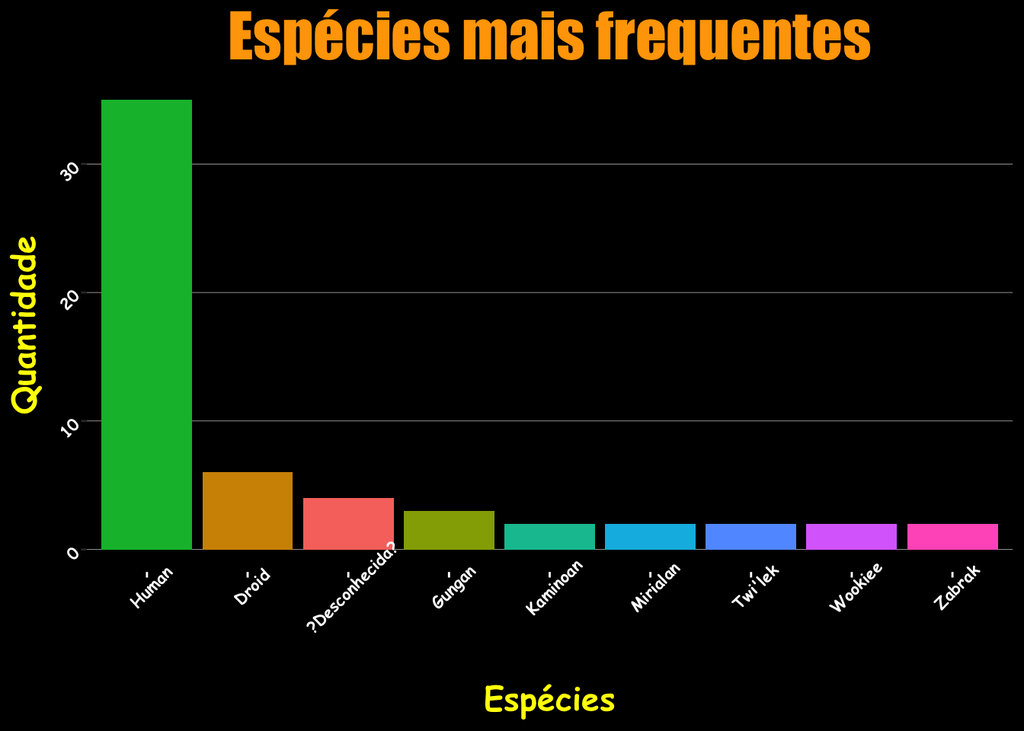

## Conclusão

A grande maioria dos personagens são humanos, afinal é uma história criada por humanos para humanos. O restante das espécies se distribuiem de forma uniforme aproximadamente.